# STATS 506 — Homework 2

Author

Yuze Jin

Published

September 28, 2026

Repository: DATASCI-506

# Problem 1 — Random Walk with Momentum

## a. Simulation function and input checks

The four direction codes represent right, left, up, and down. The first direction is random. At each later step, a Bernoulli draw decides whether to keep the previous direction; otherwise a fresh random direction is used. The fresh choice can equal the previous direction.

```r
#' Check inputs for a momentum walk
#' @param n A single positive integer number of steps.
#' @param p A single probability between 0 and 1.
#' @return Invisibly returns TRUE for valid inputs; otherwise gives an error.
check_walk_inputs <- function(n, p) {
  if (!is.numeric(n) || is.complex(n) || length(n) != 1 ||
      is.na(n) || !is.finite(n) || n < 1 || n %% 1 != 0 ||
      n > .Machine$integer.max) {
    stop("n must be a single positive integer.")
  }
  if (!is.numeric(p) || is.complex(p) || length(p) != 1 ||
      is.na(p) || !is.finite(p) || p < 0 || p > 1) {
    stop("p must be a single number between 0 and 1.")
  }
  invisible(TRUE)
}

#' Simulate a two-dimensional random walk with momentum
#' @param n A single positive integer number of steps.
#' @param p A single probability between 0 and 1.
#' @return A named vector with the final x and y coordinates.
momentum_walk <- function(n, p) {
  momentum_walk1(n, p)
}
```

The function returns the final $(x,y)$ position. Its input check requires a positive integer $n$ and a probability $p$ between 0 and 1; both implementations below use the same check.

## b. Loop and apply implementations

In Version 1, a for loop records each chosen direction. In Version 2, lapply builds a vector for each run between fresh direction draws, then unlist joins the runs. A fresh draw may select the previous direction again. In both versions, the final coordinates are the numbers of right minus left and up minus down steps.

```r
#' Simulate a momentum walk with a for loop
#' @param n A single positive integer number of steps.
#' @param p A single probability between 0 and 1.
#' @return A named vector with the final x and y coordinates.
momentum_walk1 <- function(n, p) {
  check_walk_inputs(n, p)
  n <- as.integer(n)
  random_directions <- sample(1:4, n, replace = TRUE)
  keep_previous <- runif(n) < p

  directions <- integer(n)
  directions[1] <- random_directions[1]
  if (n > 1) {
    for (i in 2:n) {
      directions[i] <- if (keep_previous[i]) {
        directions[i - 1]
      } else {
        random_directions[i]
      }
    }
  }

  c(
    x = sum(directions == 1) - sum(directions == 2),
    y = sum(directions == 3) - sum(directions == 4)
  )
}

#' Simulate a momentum walk with lapply
#' @param n A single positive integer number of steps.
#' @param p A single probability between 0 and 1.
#' @return A named vector with the final x and y coordinates.
momentum_walk2 <- function(n, p) {
  check_walk_inputs(n, p)
  n <- as.integer(n)
  random_directions <- sample(1:4, n, replace = TRUE)
  keep_previous <- runif(n) < p

  new_direction_steps <- which(c(TRUE, !keep_previous[-1]))
  run_ends <- c(new_direction_steps[-1] - 1, n)
  runs <- lapply(seq_along(new_direction_steps), function(i) {
    run_length <- run_ends[i] - new_direction_steps[i] + 1
    rep(random_directions[new_direction_steps[i]], run_length)
  })
  directions <- unlist(runs, use.names = FALSE)

  c(
    x = sum(directions == 1) - sum(directions == 2),
    y = sum(directions == 3) - sum(directions == 4)
  )
}

set.seed(506)
momentum_walk1(10, 0.6)
```

```
 x  y
-4  4
```

```r
momentum_walk2(10, 0.6)
```

```
 x  y
-1  5
```

```r
momentum_walk1(1000, 0.6)
```

```
  x   y
 34 -36
```

```r
momentum_walk2(1000, 0.6)
```

```
  x   y
-35 -63
```

The four positions vary because the calls above use successive random draws.

## c. Reproducibility

set.seed sets R’s random-number generator to the same starting state before each matched pair. Repeating a call with the same inputs and seed therefore produces the same sequence of draws and the same final position.

```r
for (n in c(10, 1000)) {
  set.seed(506)
  first <- momentum_walk1(n, 0.6)
  set.seed(506)
  second <- momentum_walk1(n, 0.6)
  cat("n =", n, "\n")
  print(rbind(first = first, second = second))
  stopifnot(identical(first, second))
}
```

```
n = 10
        x y
first  -4 4
second -4 4
n = 1000
        x   y
first  24 -38
second 24 -38
```

For both 10 and 1,000 steps, the first and second rows match. Resetting the seed before each call makes R generate the same random choices in the same order, so the final positions are reproducible.

## d. Does momentum matter in single walks?

```r
momentum_values_single <- c(0, 0.5, 0.9)
set.seed(506)
single_endpoints <- t(vapply(
  momentum_values_single,
  function(probability) momentum_walk1(1000, probability),
  c(x = 0, y = 0)
))
single_walk_results <- data.frame(
  p = momentum_values_single,
  x = single_endpoints[, "x"],
  y = single_endpoints[, "y"],
  distance = sqrt(rowSums(single_endpoints^2))
)
single_walk_results
```

```
    p   x   y distance
1 0.0 -33 -13 35.46830
2 0.5 -20   4 20.39608
3 0.9  43  55 69.81404
```

The final distances are 35.47 at $p=0$, 20.4 at $p=0.5$, and 69.81 at $p=0.9$. They do not increase steadily in these three walks, although the $p=0.9$ walk ends farthest away. One random walk per probability is not enough to establish the typical effect of momentum; part (e) uses repeated simulations.

## e. Monte Carlo simulation

replicate runs 1,000 independent walks for each probability. Each call to momentum_walk1 uses fresh random draws. The columns of endpoints contain the x and y coordinates from one walk.

```r
momentum_values <- c(0, 0.25, 0.5, 0.75, 0.9)
set.seed(506)
mean_distances <- vapply(momentum_values, function(probability) {
  endpoints <- replicate(
    1000,
    momentum_walk1(1000, probability)
  )
  mean(sqrt(colSums(endpoints^2)))
}, numeric(1))

monte_carlo_results <- data.frame(
  p = momentum_values,
  mean_distance = round(mean_distances, 2)
)
monte_carlo_results
```

```
     p mean_distance
1 0.00         27.50
2 0.25         35.94
3 0.50         47.82
4 0.75         76.27
5 0.90        121.97
```

The mean final distance rises from 27.5 at $p=0$ to 121.97 at $p=0.9$, increasing across all five probabilities in the table. Momentum makes consecutive steps more likely to point in the same direction, so a walk tends to end farther from the origin.

## f. Computational performance

The two functions follow the same random-draw mechanism and direction rules; each timed call uses fresh random values. microbenchmark times each call repeatedly, and the table compares median elapsed times in milliseconds.

```r
library(microbenchmark)
set.seed(506)
benchmark_1000 <- microbenchmark(
  loop = momentum_walk1(1000, 0.6),
  apply = momentum_walk2(1000, 0.6),
  times = 20L
)
benchmark_100000 <- microbenchmark(
  loop = momentum_walk1(100000, 0.6),
  apply = momentum_walk2(100000, 0.6),
  times = 10L
)

benchmark_results <- rbind(
  data.frame(n = 1000, summary(benchmark_1000, unit = "ms")[
    , c("expr", "median")
  ]),
  data.frame(n = 100000, summary(benchmark_100000, unit = "ms")[
    , c("expr", "median")
  ])
)
names(benchmark_results) <- c("n", "implementation", "median_ms")
benchmark_results$n <- format(
  benchmark_results$n, scientific = FALSE, trim = TRUE
)
benchmark_results$median_ms <- round(benchmark_results$median_ms, 3)
benchmark_results
```

```
       n implementation median_ms
1   1000           loop     0.050
2   1000          apply     0.199
3 100000           loop     4.750
4 100000          apply    20.967
```

On this machine, the loop is faster for both step counts. The difference in median time is much larger at 100,000 steps in absolute milliseconds. The apply version creates many separate vectors before joining them, whereas the loop directly assigns into a preallocated vector. Exact timing depends on the machine.

# Problem 2 — Monte Carlo Simulation of Campus Bus Arrivals

Each row of a matrix represents one day, and each column represents one hour in that time period. rowSums adds the hourly Poisson draws for each day. For the two peak hours, the standard deviations are the square roots of the stated variances, 4 and 5. I use the Normal draws as specified, without rounding them to integers.

```r
n_days <- 10000
set.seed(506)
morning <- matrix(rpois(n_days * 3, lambda = 4), nrow = n_days)
midday <- matrix(rpois(n_days * 6, lambda = 15), nrow = n_days)
evening <- matrix(rpois(n_days * 6, lambda = 9), nrow = n_days)
daily_passengers <- (
  rowSums(morning) +
  rnorm(n_days, mean = 45, sd = sqrt(16)) +
  rowSums(midday) +
  rnorm(n_days, mean = 55, sd = sqrt(25)) +
  rowSums(evening)
)

estimated_daily_mean <- mean(daily_passengers)
round(estimated_daily_mean, 2)
```

```
[1] 256.2
```

The Monte Carlo estimate is 256.2 passengers per day. This is close to the theoretical mean of $3(4)+45+6(15)+55+6(9)=256$. The simulation generates all 10,000 days without a loop.

# Problem 3 — Linear Regression

The data and variable definitions come from the [TidyTuesday YouTube dataset](https://github.com/rfordatascience/tidytuesday/tree/main/data/2021/2021-03-02).

## a. Data preparation and de-identification

I retain only year, the seven binary commercial characteristics, and the five engagement counts. This removes brand, URLs, title, description, channel, publication data, video identifiers, and other unused metadata.

```r
youtube <- read.csv(
  "https://raw.githubusercontent.com/rfordatascience/tidytuesday/master/data/2021/2021-03-02/youtube.csv"
)

characteristics <- c(
  "funny", "show_product_quickly", "patriotic", "celebrity",
  "danger", "animals", "use_sex"
)
engagement_counts <- c(
  "view_count", "like_count", "dislike_count",
  "favorite_count", "comment_count"
)
youtube_clean <- youtube[c("year", characteristics, engagement_counts)]
dim(youtube_clean)
```

```
[1] 247  13
```

After removing the identifying fields, the dataset has 247 rows and 13 columns. The retained columns are the variables needed for the following analyses.

## b. Exploring potential outcomes

The table reports missing values, zeros, and key quantiles for each count. A maximum far above the median indicates a long right tail.

```r
distribution_table <- do.call(rbind, lapply(engagement_counts, function(name) {
  values <- youtube_clean[[name]]
  observed <- values[!is.na(values)]
  data.frame(
    outcome = name,
    missing = sum(is.na(values)),
    zero = sum(observed == 0),
    median = median(observed),
    q75 = unname(quantile(observed, 0.75)),
    maximum = max(observed)
  )
}))
distribution_table
```

```
         outcome missing zero median       q75   maximum
1     view_count      16    0  41379 170015.50 176373378
2     like_count      22    9    130    527.00    275362
3  dislike_count      22   47      7     24.00     92990
4 favorite_count      16  231      0      0.00         0
5  comment_count      25   41     10     50.75      9190
```

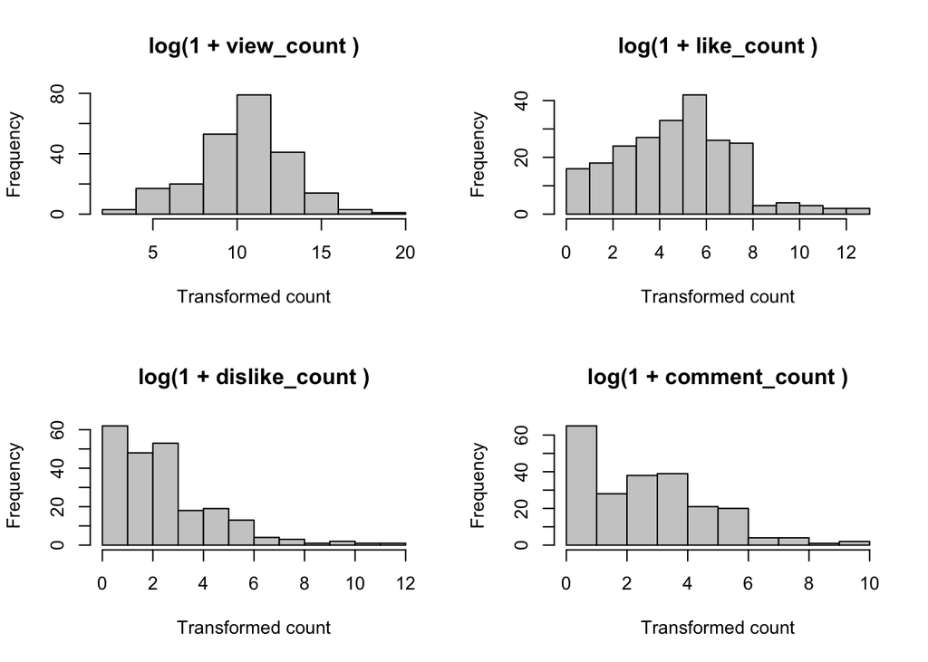

```r
par(mfrow = c(2, 2))
for (name in engagement_counts[engagement_counts != "favorite_count"]) {
  hist(
    log(1 + youtube_clean[[name]]),
    main = paste("log(1 +", name, ")"),
    xlab = "Transformed count",
    col = "gray80"
  )
}
```

```r
par(mfrow = c(1, 1))
```

Each engagement variable falls into one of the assignment’s three categories:

| Variable | Category | Reason |
| --- | --- | --- |
| View count | 2 — transform | The maximum is far above the median, showing a long right tail. |
| Like count | 2 — transform | The counts are right-skewed and include zeros. |
| Dislike count | 2 — transform | The counts have a long right tail and many zeros. |
| Favorite count | 3 — do not use | Every observed value is zero, so there is no outcome variation to model. |
| Comment count | 2 — transform | The counts have a long right tail and many zeros. |

No variable is suitable for category 1 (use unchanged). I use $\log(1+\text{count})$ for the four variables in category 2; adding 1 keeps zero counts defined. The transformed dislike and comment counts still have a large concentration near zero and a right tail; the transformation does not make them approximately normal. A linear model does not require the outcome’s overall distribution to be normal, but inference from its p-values depends on the model errors. I keep these two as exploratory transformed outcomes and would check residuals before relying on their p-values. Missing values remain missing and are omitted separately by each model.

```r
regression_outcomes <- c(
  "log_view_count", "log_like_count",
  "log_dislike_count", "log_comment_count"
)
for (name in engagement_counts[engagement_counts != "favorite_count"]) {
  youtube_clean[[paste0("log_", name)]] <- log(1 + youtube_clean[[name]])
}
```

## c. Separate linear regression models

Each model includes one binary characteristic and year as a continuous covariate. The coefficient compares commercials with and without that characteristic, conditional on year, on the log(1 + count) scale.

```r
model_results <- do.call(rbind, lapply(regression_outcomes, function(outcome) {
  do.call(rbind, lapply(characteristics, function(characteristic) {
    model_data <- data.frame(
      y = youtube_clean[[outcome]],
      characteristic = youtube_clean[[characteristic]],
      year = youtube_clean$year
    )
    model <- lm(y ~ characteristic + year, data = model_data)
    coefficient <- summary(model)$coefficients[
      "characteristicTRUE",
    ]
    data.frame(
      outcome = outcome,
      characteristic = characteristic,
      n = nobs(model),
      estimate = unname(coefficient["Estimate"]),
      p_value = unname(coefficient["Pr(>|t|)"])
    )
  }))
}))
rownames(model_results) <- NULL
data.frame(
  outcome = model_results$outcome,
  characteristic = model_results$characteristic,
  n = model_results$n,
  estimate = round(model_results$estimate, 3),
  p_value = signif(model_results$p_value, 3)
)
```

```
             outcome       characteristic   n estimate p_value
1     log_view_count                funny 231    0.530  0.2050
2     log_view_count show_product_quickly 231    0.209  0.6010
3     log_view_count            patriotic 231    0.137  0.7840
4     log_view_count            celebrity 231   -0.019  0.9630
5     log_view_count               danger 231    0.667  0.0941
6     log_view_count              animals 231   -0.173  0.6470
7     log_view_count              use_sex 231   -0.296  0.4910
8     log_like_count                funny 225    0.360  0.3400
9     log_like_count show_product_quickly 225    0.168  0.6400
10    log_like_count            patriotic 225    0.493  0.2900
11    log_like_count            celebrity 225    0.263  0.4780
12    log_like_count               danger 225    0.625  0.0803
13    log_like_count              animals 225    0.025  0.9430
14    log_like_count              use_sex 225   -0.325  0.4000
15 log_dislike_count                funny 225    0.041  0.8960
16 log_dislike_count show_product_quickly 225    0.243  0.4210
17 log_dislike_count            patriotic 225    0.670  0.0856
18 log_dislike_count            celebrity 225   -0.283  0.3620
19 log_dislike_count               danger 225    0.185  0.5380
20 log_dislike_count              animals 225   -0.074  0.7970
21 log_dislike_count              use_sex 225   -0.389  0.2290
22 log_comment_count                funny 222    0.047  0.8790
23 log_comment_count show_product_quickly 222    0.346  0.2470
24 log_comment_count            patriotic 222    0.515  0.1690
25 log_comment_count            celebrity 222    0.228  0.4560
26 log_comment_count               danger 222    0.106  0.7210
27 log_comment_count              animals 222   -0.192  0.4990
28 log_comment_count              use_sex 222   -0.349  0.2740
```

```r
significant_results <- model_results[model_results$p_value < 0.05, ]
significant_results
```

```
[1] outcome        characteristic n              estimate       p_value
<0 rows> (or 0-length row.names)
```

```r
view_results <- model_results[
  model_results$outcome == "log_view_count",
]
largest_positive_view <- view_results[
  which.max(view_results$estimate),
]
largest_positive_view
```

```
         outcome characteristic   n  estimate    p_value
5 log_view_count         danger 231 0.6667808 0.09406479
```

At the $\alpha=0.05$ level, **none** of the seven characteristics is significantly associated with any of the four outcomes: transformed views, likes, dislikes, or comments. Therefore, there are no significant positive or negative associations to list. The danger characteristic has the largest positive estimated association with transformed view count (coefficient 0.667), but its p-value of 0.094 is above 0.05. These separate observational models do not establish causation.

## d. Regression coefficients by matrix algebra

I select the characteristic with the smallest view-count p-value in part (c). The matrix calculation and lm comparison use the same complete cases and predictors.

```r
selected_characteristic <- view_results$characteristic[
  which.min(view_results$p_value)
]
regression_data <- data.frame(
  y = youtube_clean$log_view_count,
  characteristic = youtube_clean[[selected_characteristic]],
  year = youtube_clean$year
)
regression_data <- regression_data[complete.cases(regression_data), ]

X <- cbind(
  "(Intercept)" = 1,
  as.integer(regression_data$characteristic),
  year = regression_data$year
)
colnames(X)[2] <- selected_characteristic
y <- regression_data$y

beta_matrix <- solve(t(X) %*% X, t(X) %*% y)
comparison_model <- lm(y ~ characteristic + year, data = regression_data)
beta_lm <- unname(coef(comparison_model))
coefficient_comparison <- data.frame(
  term = colnames(X),
  matrix_estimate = as.vector(beta_matrix),
  lm_estimate = beta_lm,
  absolute_difference = abs(as.vector(beta_matrix) - beta_lm)
)
selected_characteristic
```

```
[1] "danger"
```

```r
coefficient_comparison
```

```
         term matrix_estimate  lm_estimate absolute_difference
1 (Intercept)    -31.39149243 -31.39149243        4.247163e-10
2      danger      0.66678076   0.66678076        2.325917e-13
3        year      0.02065641   0.02065641        2.112442e-13
```

The selected characteristic is danger. The design matrix has columns for the intercept, that characteristic, and year. The call to `solve()` solves $X^\top X\hat{\beta}=X^\top y$, which is equivalent to the requested matrix formula. The largest absolute difference between the matrix estimates and `lm()` estimates is less than $10^{-9}$, so they agree up to numerical precision. The small differences arise because the normal-equation calculation and `lm()` use different numerical methods.

# Sources and assistance

OpenAI Codex assisted with drafting and checking the R code and explanations. The YouTube dataset and its variable descriptions are from [TidyTuesday](https://github.com/rfordatascience/tidytuesday/tree/main/data/2021/2021-03-02).